# Module 11 Lecture - Chi-squared Tests

Introduction to Statistical Methods

Quinton Quagliano, M.S., C.S.P

Department of Educational Psychology

# 1 Overview and Introduction

Agenda

1 Overview and Introduction

2 Basics of the Chi-Square Distribution

3 Goodness-of-Fit Test

4 Test of Independence

5 Test of Homogeneity

6 Conclusion

## 1.1 Textbook Learning Objectives

- Interpret the chi-square probability distribution as the sample size changes.
- Conduct and interpret chi-square goodness-of-fit hypothesis tests.
- Conduct and interpret chi-square test of independence hypothesis tests.
- Conduct and interpret chi-square homogeneity hypothesis tests.

## 1.2 Instructor Learning Objectives

- Appreciate how the chi-square family of tests largely depart from the previous mean-based testing in t-tests
- Understand what scenarios each form of the chi-square test may be appropriate to
- See how the chi-square family of tests add to our toolbox of inferential tests

## 1.3 Introduction

- The $\chi^2$ distribution, also known as **chi-square distribution**, or chi-squared distribution is a unique tool that can be applied in inferential testing
  - Much like the t-distribution, the chi-square distribution serves a purpose of comparison
- There are 3 primary uses for the chi-square distribution:
  - Goodness-of-fit: to compare if data is distributed as expected
  - Test of independence: to compare if two events are independent
  - Test of homogeneity: to test if two distribution are the same as one another
- **Important: Though not explicitly mentioned in the book, the chi-square distribution is particularly well-suited to helping us make sense of categorical data - but that is not the ONLY way it can be used**

# 2 Basics of the Chi-Square Distribution

Agenda

1 Overview and Introduction

2 Basics of the Chi-Square Distribution

3 Goodness-of-Fit Test

4 Test of Independence

5 Test of Homogeneity

6 Conclusion

## 2.1 Formula & Notation

- **Discuss: Review: Write out the notation for Student's t-distribution**
- Formula for $\chi^2$ distribution:
  - $X \sim \chi^2_{df}$
  - Where:
    - $df$: degrees of freedom
    - $X$: a random variable (much like other distributions, this can really be any uppercase letter, X is just convention)
    - $\chi^2$: arbitrary notation for the chi-square distribution

## 2.2 Distribution Characteristics

- **Discuss: Review: Think back to our initial discussions on the uniform and exponential distributions - write out the formulas for the find long-term mean and standard deviation in those distributions?**
- Characteristics of the distribution:
  - $\mu = df$
  - $\sigma = \sqrt{2(df)}$
  - The curve is nonsymmetrical and skewed to the right
  - The chi-square curve for each $df$
  - The test statistic for any test is always greater than or equal to 0
  - When $df > 90$, the chi-square distribution is approximately normal
  - The $\mu$ is located to the near right of the “peak” of the curve

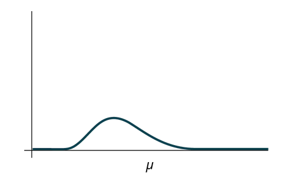

- The $\chi^2$ distribution thus changes dependent on the degrees of freedom

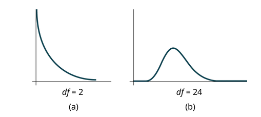

## 2.3 The df for Chi-square Distribution

- So how does one calculate the important $df$ for this distribution?
  - Depends on which of the 3 use cases we are implementing
- **Discuss: Try explaining, in your own words, what degrees of freedom are again?**
- **Important: The fact that the chi-square distribution changes dependent on the df is a unique change compared to the normal or t-distributions!**

# 3 Goodness-of-Fit Test

Agenda

1 Overview and Introduction

2 Basics of the Chi-Square Distribution

3 Goodness-of-Fit Test

4 Test of Independence

5 Test of Homogeneity

6 Conclusion

## 3.1 Introduction

- The **goodness-of-fit test** is an application where the chi-square distribution is used to determine whether data “fits” a certain distribution
- **Discuss: Why might we want to know if the data we have fit a certain distribution? hint: think about 'assumptions'**

## 3.2 Formula

$$\chi^2 = \sum_k\frac{(O - E)^2}{E}$$

$$df = k - 1$$

- Where:
  - O = **observed values** are those that we actually measure from our sample
  - E = **expected values** are those that we expect our observed values to be if they follow the same distribution, i.e., if the null hypothesis is true
  - $k$ = the number of different categories, you can think of this as the “pairs” of observed and expected data points
- **Discuss: A chi-square statistic characteristic is always equal to or greater than 0; explain why this characteristic is true by looking at the formula**
- **Important: Due to some mathematical oddities, don't use this unless expected values are at least 5 or greater in each category - can inflate type I error**

## 3.3 Null and Alternative Hypotheses Testing

- **Important: Null and alternative hypotheses can and should be stated when doing any and all inferential testing! Still applies here**
- Hypothesis pair:
  - Null hypothesis: The observed values/proportions are the same as the expected values
  - Alternative hypothesis: The observed values/proportions are different than the expected values
- Goodness-fit-tests are usually done in right-tailed manner, as a greater statistic suggest a greater divergence from expected distribution
- **Discuss: Draw a normal curve and shade it in such a manner to show a right-tailed test**

## 3.4 Application Example

- I have a class of 20 students, who I expect will have a uniform distribution of As, Bs, Cs, Ds, and Fs
  - $E: \{4, 4, 4, 4, 4\}$
  - $O: \{2, 4, 12, 1, 1\}$
- Hypothesis pair:
  - $H_0:$ the observed letter grades fits the expected distribution of 4 of each A, B, C, D, F
  - $H_A:$ the observed letter grades do not fit the expected distribution of 4 of each A, B, C, D, F

| Grade | Expected (E) | Observed (O) | (O − E) | ’’ / E |
| --- | --- | --- | --- | --- |
| A | 4 | 2 | -2 | (−2)² / 4 = 1.00 |
| B | 4 | 4 | 0 | 0.00 |
| C | 4 | 12 | 8 | 8² / 4 = 16.00 |
| D | 4 | 1 | -3 | (−3)² / 4 = 2.25 |
| F | 4 | 1 | -3 | (−3)² / 4 = 2.25 |
| **Total** | 20 | 20 | — | **21.50** |

- $\chi^2 = 21.50$, $df = 5 - 1 = 4$
  - $p$ to be determined by computer and compared against arbitrary $\alpha$
- **Discuss: Do the same process as demonstrated above, but now using 1,1,1,2,15 as the observed data**

# 4 Test of Independence

Agenda

1 Overview and Introduction

2 Basics of the Chi-Square Distribution

3 Goodness-of-Fit Test

4 Test of Independence

5 Test of Homogeneity

6 Conclusion

## 4.1 Introduction

- The **test of independence test** is used when we want to determine if two factors or variables are independent or not
  - This test will use a **contingency table** that shows frequencies of two variable in data
- **Discuss: Think back to our probability units, what did 'independent' mean in that context and how did it relate to sampling?**
- **Important: Much like goodness-of-fit, don't use this unless expected values are at least 5 or greater in each category - can inflate type I error**

## 4.2 Formula

$$\chi^2 = \sum_{i * j}\frac{(O - E)^2}{E}$$

$$df = (i - 1) * (j - 1)$$

- Where:
  - $O:$ observed values
  - $E:$ expected values*
  - $i:$ number of rows in the data
  - $j:$ number of columns in the data
- Expected value ($E$) for each cell of the table is calculated as:
  - $E = \frac{\sum_{row} * \sum_{column}}{{\sum_{total}}}$

## 4.3 Null and Alternative Hypotheses Testing

- Hypothesis pair:
  - Null hypothesis: The two factors are independent
  - Alternative hypothesis: The two factors are dependent

## 4.4 Application Example

- I have a class of 40 students, half of whom are female and half are male, and below are their counts of of As, Bs, Cs, Ds, and Fs
  - $F: \{6, 5, 3, 5, 1\}$
  - $M: \{3, 4, 4, 7, 2\}$
- Hypothesis pair:
  - $H_0:$ The two factors of sex and grade are independent
  - $H_A:$ The two factors of sex and grade are dependent
- Contingency Table:

| Grade | Female (F) | Male (M) | Total |
| --- | --- | --- | --- |
| A | 6 | 3 | 9 |
| B | 5 | 4 | 9 |
| C | 3 | 4 | 7 |
| D | 5 | 7 | 12 |
| F | 1 | 2 | 3 |
| **Total** | **20** | **20** | **40** |

- Expected Counts:

| Grade | Female (E) | Male (E) |
| --- | --- | --- |
| A | 9×20/40 = 4.5 | 4.5 |
| B | 9×20/40 = 4.5 | 4.5 |
| C | 7×20/40 = 3.5 | 3.5 |
| D | 12×20/40 = 6.0 | 6.0 |
| F | 3×20/40 = 1.5 | 1.5 |

- Chi-square statistic:

| Grade | Female (O−E)²/E | Male (O−E)²/E |
| --- | --- | --- |
| A | (6−4.5)²/4.5 = 0.50 | (3−4.5)²/4.5 = 0.50 |
| B | (5−4.5)²/4.5 = 0.06 | (4−4.5)²/4.5 = 0.06 |
| C | (3−3.5)²/3.5 = 0.07 | (4−3.5)²/3.5 = 0.07 |
| D | (5−6.0)²/6.0 = 0.17 | (7−6.0)²/6.0 = 0.17 |
| F | (1−1.5)²/1.5 = 0.17 | (2−1.5)²/1.5 = 0.17 |
| **Total χ² = 1.94** |  |  |

- $df = (5 - 1)(2 - 1) = 4$, $p$ to be calculated by computer
- **Discuss: Do the same process as demonstrated above, but now using F: 1,1,1,2,15 and M: 2,2,2,10,4 as the observed data**

# 5 Test of Homogeneity

Agenda

1 Overview and Introduction

2 Basics of the Chi-Square Distribution

3 Goodness-of-Fit Test

4 Test of Independence

5 Test of Homogeneity

6 Conclusion

## 5.1 Introduction

- Whereas the goodness-of-fit test can tell us whether data matches a specified, known distribution, we have a different test for testing whether two different sets of data follow the same, unknown distribution
  - We call these are **test for homogeneity**
- **Discuss: In what hypothesis testing scenarios might we want to know whether two sets of data seem to have equal distributions? hint: think independent-samples t-test**

## 5.2 Formula

$$\chi^2 = \sum_{i * j}\frac{(O - E)^2}{E}$$

$$df = (i - 1) * (j - 1)$$

## 5.3 Null and Alternative Hypotheses Testing

- Hypothesis pair:
  - Null hypothesis: The distributions of the two populations are the same
  - Alternative hypothesis: The distributions of the two populations are not the same

## 5.4 Application Example

| Class | Female (F) | Male (M) | Total |
| --- | --- | --- | --- |
| Freshman | 6 | 5 | 11 |
| Sophomore | 14 | 7 | 21 |
| Junior | 8 | 7 | 15 |
| Senior | 12 | 8 | 20 |
| **Total** | **40** | **27** | **67** |

- Expected counts

| Class | Expected F | Expected M |
| --- | --- | --- |
| Freshman | 6.57 | 4.43 |
| Sophomore | 12.54 | 8.46 |
| Junior | 8.96 | 6.04 |
| Senior | 11.94 | 8.06 |

- Chi-square calculation

| Class | Group | (O) | (E) | ((O-E)^2/E) |
| --- | --- | --- | --- | --- |
| Freshman | F | 6 | 6.57 | 0.049 |
| Freshman | M | 5 | 4.43 | 0.074 |
| Sophomore | F | 14 | 12.54 | 0.170 |
| Sophomore | M | 7 | 8.46 | 0.252 |
| Junior | F | 8 | 8.96 | 0.103 |
| Junior | M | 7 | 6.04 | 0.151 |
| Senior | F | 12 | 11.94 | 0.0003 |
| Senior | M | 8 | 8.06 | 0.0004 |

# 6 Conclusion

Agenda

1 Overview and Introduction

2 Basics of the Chi-Square Distribution

3 Goodness-of-Fit Test

4 Test of Independence

5 Test of Homogeneity

6 Conclusion

## 6.1 Recap

- The chi-squared distribution is well suited to dealing with categorical counts and proportions, but the 3 forms of the chi-square distribution have somewhat different application and formulas
- The shape of the chi-square distribution changes based upon the dfs, and the hypothesis testing done with it is usually right-tailed, among other consistent characteristics
- Like with the other distributions we have discussed, be mindful of how the null and alternative hypotheses change

## 6.2 Lecture Check-in

- Make sure to complete any lecture check-in tasks associated with this lecture!

[figure not shown]

Module 11 Lecture - Chi-squared Tests || Introduction to Statistical Methods